# Introducción a SVM en R

La librería de SVM que se usará para este taller es libSVM. Puede consultarse en la dirección https://www.csie.ntu.edu.tw/~cjlin/libsvm/

En R se debe cargar la librería e1071 que contiene funciones desarrolladas en el proyecto libSVM.

Probaremos las SVM inicialmente con el conjunto de datos “iris”. Este conjunto de datos se puede apreciar en la página:

https://en.wikipedia.org/wiki/Iris_flower_data_set.

```r
#install.packages("e1071")
library("e1071")

#Cargamos el dataset
iris.dataset = iris
#volvemos categorico la columna "Species"
iris.dataset[, "Species"] <-as.factor(iris.dataset[, "Species"])

#Generamos conjunto de entrenamiento.
set.seed(1234) # semilla
muestra.cantidad <- floor(0.7 * nrow(iris.dataset)) #Obtenemos el tamaño del conjunto de entrenamiento
entrenamiento.index <- sample(seq_len(nrow(iris.dataset)), size = muestra.cantidad) #Obtenemos los index de los datos que van a servir de enttenamiento
conjunto_entrenamiento <- iris.dataset[entrenamiento.index, ] #Conjunto de entrenamiento

#Generamos conjunto de prueba.
conjunto_prueba <- iris.dataset[- entrenamiento.index, ] #Conjunto de Prueba, toma los index que no son de entrenamaiento


#Entrenamos una SVM de Kernel Radial y de tipo C-Classification.
modelrad <- svm(Species~ ., data=conjunto_entrenamiento,  cost = 1, gamma = 0.25, type = "C-classification", kernel="radial")
predrad <- predict(modelrad, conjunto_prueba)
table(predrad, conjunto_prueba[, "Species"])
```

```
##
## predrad      setosa versicolor virginica
##   setosa         11          0         0
##   versicolor      0         20         1
##   virginica       0          1        12
```

```r
#print(modelrad)
```

Las opciones para correr la SVM se pueden ver al ejecutar help(svm).

Existen diferentes tipos de kernel:

Kernel radial: Es el más general, tiene dos parámetros que en algunos casos se comporta igual que el kernel linear.

Kernel linear: se recomienda usar cuando se tienen más características que vectores para clasificar.

Kernel polynomial: es popular su uso en procesamiento de lenguaje natural; pero puede generar inestabilidad numérica.

Kernel sigmoidal: Similar al funcionamiento de un perceptron.

Tomado de:

https://stats.stackexchange.com/questions/237382/difference-between-the-types-of-svm

C-classification and nu-classification is for binary classification usage. Say if you want to build a model to classify cat vs. dog based on features for animals, i.e., prediction target is a discrete variable/label.

For details about difference between C-classification and nu-classification. You can find in the FAQ from LIBSVM

```
Q: What is the difference between nu-SVC and C-SVC?

Basically they are the same thing but with different parameters. The range of C is from zero to infinity but nu is always between [0,1]. A nice property of nu is that it is related to the ratio of support vectors and the ratio of the training error.
```

One-classification is for “outlier detection”, where you only have one classes data. For example, you want to detect “unusual” behaviors of one user’s account. But you do not have “unusual behavior” to train the model. But only the normal behavior.

Las SVM se pueden “sintonizar”. Para esto, se puede usar la función tune.svm. Para hacer la sintonización, se definen el rango de búsqueda de los parámetros en los que se buscará el mejor modelo, y al final se saca el modelo con el mejor desempeño.

```r
modelos = tune.svm(Species~ ., data=conjunto_entrenamiento, cost=1:10, gamma=seq(0,3,0.1), kernel="radial")

best_mod <- modelos$best.model

pred_best <- predict(best_mod)

table(pred_best, conjunto_entrenamiento$Species)
```

```
##
## pred_best    setosa versicolor virginica
##   setosa         39          0         0
##   versicolor      0         29         0
##   virginica       0          0        37
```

La predicción con el mejor modelo es:

```r
testPred <- predict(best_mod, newdata = conjunto_prueba)
table(testPred, conjunto_prueba$Species)
```

```
##
## testPred     setosa versicolor virginica
##   setosa         11          0         0
##   versicolor      0         19         1
##   virginica       0          2        12
```

JUGUEMOS CON DATOS FICTICIOS.

https://www4.stat.ncsu.edu/~reich/BigData/code/SVM.html

Generamos un set de datos a separar.

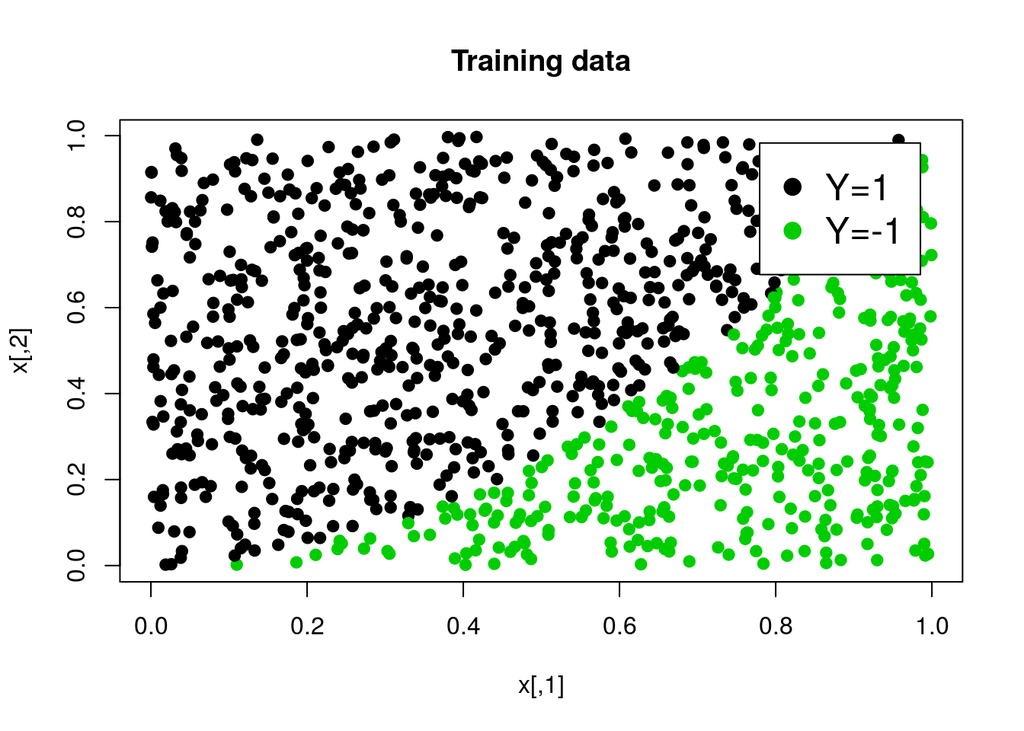

```r
n <- 1000

# Datos de entrenamiento
 x <- cbind(runif(n),runif(n))
 y <- ifelse(x[,2] > x[,1]^2,1,-1)

 #Datos de test
 xp <- cbind(runif(2*n),runif(2*n))
 yp <- ifelse(xp[,2] > xp[,1]^2,1,-1)

 # configuracion
 y   <- as.factor(y)
 yp  <- as.factor(yp)
 x1  <- x
 z1  <- xp

 plot(x,col=ifelse(y=="1",1,3),pch=19,main="Training data")
 legend("topright",c("Y=1","Y=-1"),pch=19,col=c(1,3),inset=0.05,bg=gray(1),cex=1.5)
```

Entrenamos una SVM Lineal para clasificar los datos.

```r
mod1 <- svm(x1,y,kernel="linear")
```

Podemos revisar cuáles son los vectores de soporte calculados con la SVM.

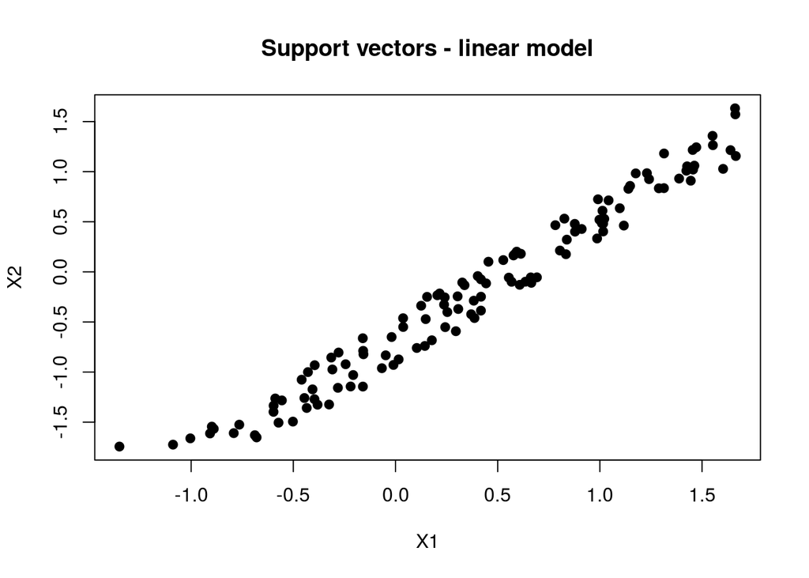

```r
#veamos los vectores de soporte
plot(mod1$SV,pch=19,main="Support vectors - linear model")
```

Probemos con un Kernel radial

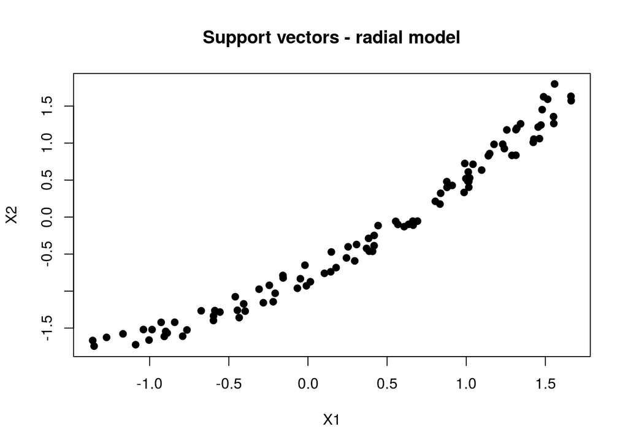

```r
mod2 <- svm(x1,y,kernel="radial",gamma=0.1,cost=10)
plot(mod2$SV,pch=19,main="Support vectors - radial model")
```

Probemos la prediccion de ambos modelos.

```r
 yhat1 <- predict(mod1,z1)
 yhat2 <- predict(mod2,z1)
 table(yp,yhat1)
```

```
##     yhat1
## yp     -1    1
##   -1  665   41
##   1    37 1257
```

```r
 table(yp,yhat2)
```

```
##     yhat2
## yp     -1    1
##   -1  695   11
##   1    18 1276
```

Podemos calcular el área bajo la curva ROC para ver cuál es mejor.

```r
library(ROCR)
roc_predlin <- prediction(as.numeric(yhat1), as.numeric(yp))
auclin <- performance(roc_predlin, "auc")
auclin <- unlist(slot(auclin, "y.values"))
auclin
```

```
## [1] 0.9566664
```

```r
roc_predrad <- prediction(as.numeric(yhat2), as.numeric(yp))
aucrad <- performance(roc_predrad, "auc")
aucrad <- unlist(slot(aucrad, "y.values"))
aucrad
```

```
## [1] 0.9852545
```

Podemos ver las clasificaciones que hace cada SVM:

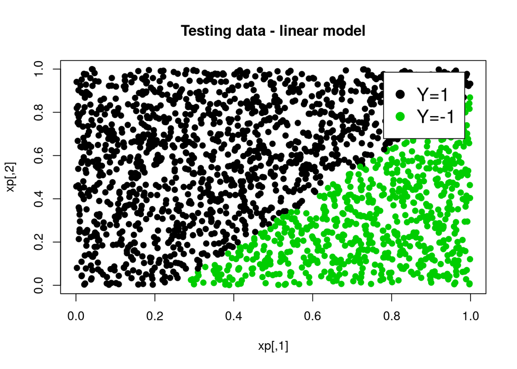

```r
 plot(xp,col=ifelse(yhat1=="1",1,3),pch=19,main="Testing data - linear model")
 legend("topright",c("Y=1","Y=-1"),pch=19,col=c(1,3),inset=0.05,bg=gray(1),cex=1.5)
```

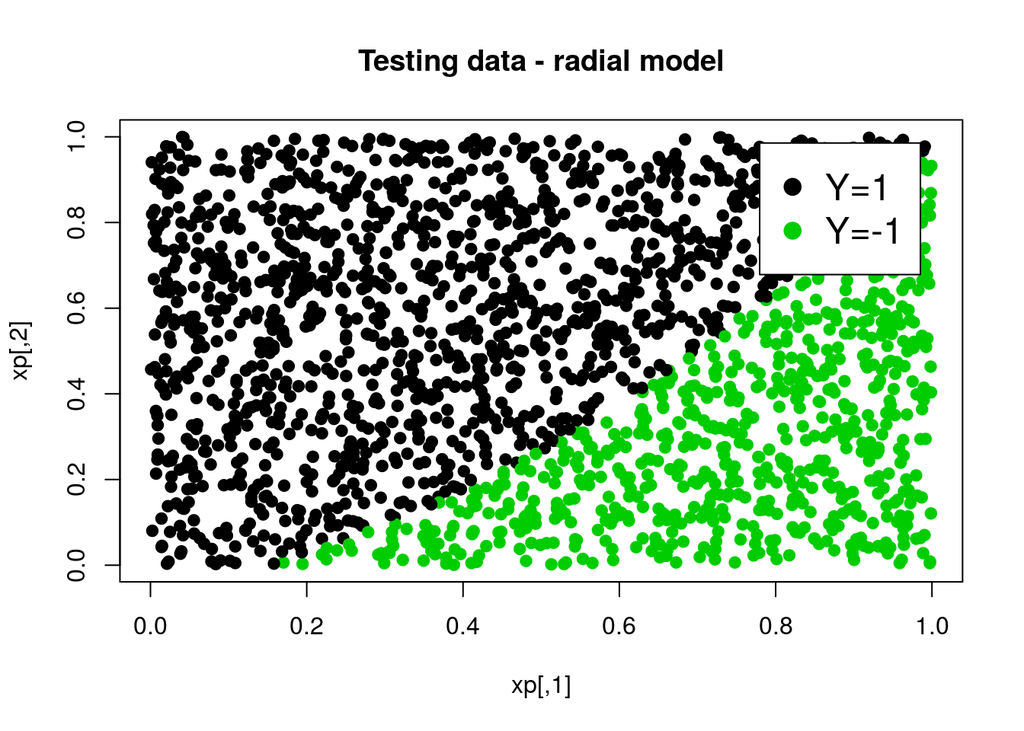

```r
plot(xp,col=ifelse(yhat2=="1",1,3),pch=19,main="Testing data - radial model")
 legend("topright",c("Y=1","Y=-1"),pch=19,col=c(1,3),inset=0.05,bg=gray(1),cex=1.5)
```

TAREA: Encontrar (si existe) una mejor SVM con mejores parámetros para este caso.